# IUCN Palette

Make your plots with the official colours used by the IUCN according to their style guide.

I wanted to give a bit more on the package I made for using IUCN palette colours in in R. I built this as I wanted to do just that, align the data I was representing with the official colours of the IUCN. The framework for the package was the Wes Anderson (package)[https://github.com/karthik/wesanderson] which made this fairly simple for me. I built some additional features to it though as people would be more likely to need only select colours.

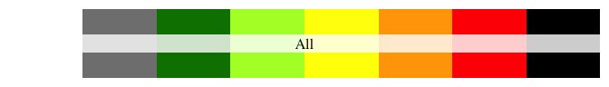

All colours: `iucn_palette()`

The additional features are passed as arguments to the main function ‘iucn_palette’ where you can exclude certain colours (exclude the colour for ‘Extinct’ for example), or where you can select to just use one (select only ‘Endangered’).

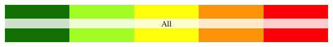

Select colours: `iucn_palette(exclude=c("DD", "NE", "CO"))`

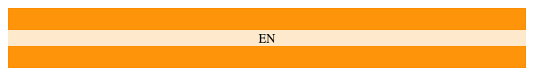

Single colour: `iucn_palette(category="EN")`

Practically, if you’re only using one this isn’t that different from putting the hexcode yourself, but the package does allow you to easily switch between them and access these colours when you need.

I used this to make a simple graphic in [another post](https://timcashion.github.io/iucn_classifier/) as well.

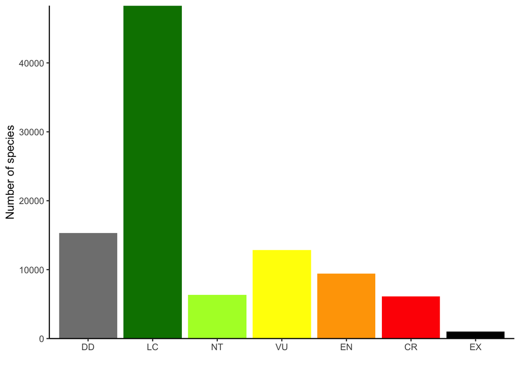

You can find the source code for the package here: https://github.com/timcashion/IUCNpalette